# Homework

## Homework-11.17

## Question1

Implement a random walk Metropolis sampler for generating the standard Laplace distribution (see Exercise 3.2). For the increment, simulate from a normal distribution. Compare the chains generated when different variances are used for the proposal distribution. Also, compute the acceptance rates of each chain.

## Answer

```r
options(warn = -1)
library(GeneralizedHyperbolic)
Laplace.Metropolis <- function(sigma, N){
  x <- numeric(N)
  x[1] <- rnorm(1,0,sigma)
  u <- runif(N)
  k <- 0
  for (i in 2:N) {
    y <- rnorm(1, x[i-1], sigma)
    if(u[i] <= dskewlap(y)/dskewlap(x[i-1]))
      x[i] <- y
    else{
      x[i] <- x[i-1]
      k <- k+1
    }
  }
  return(list(x = x, k = k))
}
N <- 1e4
sigma <- c(1, 4, 9, 16)
set.seed(1234)
laplace1<-Laplace.Metropolis(sigma[1], N)
laplace2<-Laplace.Metropolis(sigma[2], N)
laplace3<-Laplace.Metropolis(sigma[3], N)
laplace4<-Laplace.Metropolis(sigma[4], N)
df <- data.frame(c(1-laplace1$k/N,1-laplace2$k/N,1-laplace3$k/N,1-laplace4$k/N))
names(df) <- c("acceptance rate")
rownames(df) <- c("sigma=1", "sigma=4", "sigma=9", "sigma=16")
knitr::kable(df)
```

|  | acceptance rate |
| --- | --- |
| sigma=1 | 0.7018 |
| sigma=4 | 0.3509 |
| sigma=9 | 0.1645 |
| sigma=16 | 0.0944 |

We can see that the acceptance rate decreased while the variance increased.

## Question2

For Exercise 9.4, use the Gelman-Rubin method to monitor convergence of the chain, and run the chain until it converges approximately to the target distribution according to $\hat{R}<1.2$.

## Answer

```r
Gelman.Rubin <- function(psi) {
# psi[i,j] is the statistic psi(X[i,1:j])
# for chain in i-th row of X
psi <- as.matrix(psi)
n <- ncol(psi)
k <- nrow(psi)
psi.means <- rowMeans(psi) #row means
B <- n * var(psi.means) #between variance est.
psi.w <- apply(psi, 1, "var") #within variances
W <- mean(psi.w) #within est.
v.hat <- W*(n-1)/n + (B/n) #upper variance est.
r.hat <- v.hat / W #G-R statistic
return(r.hat)
}
Laplace.Metropolis <- function(sigma, N, X1){
  x <- numeric(N)
  x[1] <- X1
  u <- runif(N)
  k <- 0
  for (i in 2:N) {
    y <- rnorm(1,x[i-1],sigma)
    if(u[i] <= dskewlap(y)/dskewlap(x[i-1]))
      x[i] <- y
    else{
      x[i] <- x[i-1]
      k <- k+1
    }
  }
  return(x)
}
k <- 4 #number of chains to generate
n <- 15000
b <- 1000
sigma <- 1
x0 <- c(-10, -5, 5, 10)
X <- matrix(0, nrow=k, ncol=n)
for (i in 1:k)
X[i, ] <- Laplace.Metropolis(sigma, n, x0[i])

psi <- t(apply(X, 1, cumsum))
for (i in 1:nrow(psi))
psi[i,] <- psi[i,] / (1:ncol(psi))
print(Gelman.Rubin(psi))
```

```
## [1] 1.070582
```

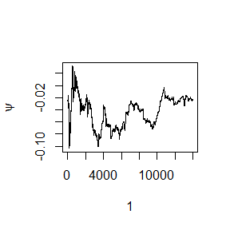

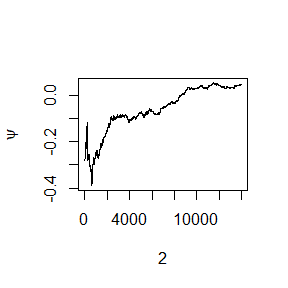

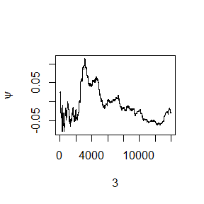

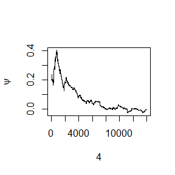

```r
#plot psi for the four chains
for (i in 1:k)
plot(psi[i, (b+1):n], type="l",
xlab=i, ylab=bquote(psi))
```

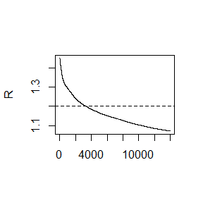

```r
par(mfrow=c(1,1)) #restore default
#plot the sequence of R-hat statistics
rhat <- rep(0,n)
for (j in (b+1):n)
rhat[j] <- Gelman.Rubin(psi[,1:j])
plot(rhat[(b+1):n], type="l", xlab="", ylab="R")
abline(h=1.2, lty=2)
```

## Question3

Find the intersection points $A(k)$ in $(0,\sqrt{k})$ of the curves
$$S_{k-1}(a)=P( t(k-1)>\sqrt{\frac{a^2(k-1)}{k-a^2}} )$$
and
$$S_{k}(a)=P( t(k)>\sqrt{\frac{a^2k}{k+1-a^2}} ),$$
for $k=4:25,100,500,1000,$ where $t(k)$ is a Student $t$ random variable with $k$ degrees of freedom. (These intersection points determine the critical values for a t-test for scale-mixture errors proposed by $Sz\acute{e}kely$ [260].)

## Answer

Use uniroot function to get the intersection points’ abscissa.

```r
u <- c(seq(4,25),100,500,1000)
b <- numeric(length(u))
c <- numeric(length(u))
s1 <- function(a){   #S_k-1
  1-pt(sqrt(a^2*(k-1)/(k-a^2)),k-1)
}
s2 <- function(a){   #S_k
  1-pt(sqrt(a^2*k/(k+1-a^2)),k)
}
s <- function(a){   #s1-s2
  1-pt(sqrt(a^2*(k-1)/(k-a^2)),k-1)-(1-pt(sqrt(a^2*k/(k+1-a^2)),k))
}
for(i in 1:length(u)){
  k <- u[i]
  b[i] <- uniroot(s,c(0.01,2))$root    #get root
  c[i] <- s1(b[i])
}

df2 <- data.frame(u,b,c)
names(df2) <- c("k", "abscissa", "Y-axis")
knitr::kable(df2)
```

| k | abscissa | Y-axis |
| --- | --- | --- |
| 4 | 1.492103 | 0.0738151 |
| 5 | 1.533554 | 0.0662763 |
| 6 | 1.562745 | 0.0615686 |
| 7 | 1.584430 | 0.0583593 |
| 8 | 1.601185 | 0.0560342 |
| 9 | 1.614522 | 0.0542735 |
| 10 | 1.625391 | 0.0528947 |
| 11 | 1.634420 | 0.0517861 |
| 12 | 1.642039 | 0.0508755 |
| 13 | 1.648555 | 0.0501144 |
| 14 | 1.654192 | 0.0494688 |
| 15 | 1.659115 | 0.0489143 |
| 16 | 1.663453 | 0.0484329 |
| 17 | 1.667305 | 0.0480111 |
| 18 | 1.670746 | 0.0476385 |
| 19 | 1.673841 | 0.0473070 |
| 20 | 1.676638 | 0.0470101 |
| 21 | 1.679179 | 0.0467426 |
| 22 | 1.681497 | 0.0465005 |
| 23 | 1.683620 | 0.0462803 |
| 24 | 1.685573 | 0.0460791 |
| 25 | 1.687374 | 0.0458945 |
| 100 | 1.720606 | 0.0426690 |
| 500 | 1.729753 | 0.0418375 |
| 1000 | 1.730905 | 0.0417344 |

## Homework-11.24

## Question1

- A-B-O blood type problem
- Let the three alleles be A, B, and O.

  ```
    |          |    |    |    |    |    |    |    |
    |:---------|:---|:---|:---|:---|:---|:---|:---|
    |Genotype  |AA  |BB  |OO  |AO  |BO  |AB  |Sum |
    |Frequency |p^2 |q^2 |r^2 |2pr |2qr |2pq |1   |
    |Count     |nAA |nBB |nOO |nAO |nBO |nAB |n   |
  ```

- Observed data: $n_{A\cdot}=n_{AA}+n_{AO}=444$ (A-type), $n_{B\cdot}=n_{BB}+n_{BO}=132$ (B-type), $n_{OO}=361$ (O-type), $n_{AB}=63$ (AB-type).
- Use EM algorithm to solve MLE of $p$ and $q$ (consider missing data $n_{AA}$ and $n_{BB}$).
- Record the values of p and q that maximize the conditional likelihood in each EM steps, calculate the corresponding log-maximum likelihood values (for observed data), are they increasing?

## Answer

We can obtain the log-likelihood which is
$$l(p,q|n_{AA},n_{BB},n_{OO},n_{A.},n_{B.},n_{AB})=2n_{AA}log(p)+2n_{BB}log(q)+2n_{OO}log(r)+(n_{A.}-n_{AA})log(2pr)+(n_{B.}-n_{BB})log(2qr)+n_{AB}log(2pq),$$
where $r=1-p-q$.

```r
p0 <- 0.5; q0 <- 0.3                                   # initial value
nA <- 444; nB <- 132; nOO <- 361; nAB <- 63            # data
tol <- .Machine$double.eps^0.5                         # tolerance
N <- 10000
p <- p0; q <- q0
logl <- numeric(N)                                     # log-likelihood
k <- 1
L.old <- c(p0, q0)
for (i in 1:N) {
  r <- 1-p-q
  a <- p/(2-p-2*q)
  b <- q/(2-2*p-q)
  Hp <- nA*(1+a)+nAB
  Hq <- nB*(1+b)+nAB
  Hr <- nA*(1-a)+nB*(1-b)+2*nOO
  H2 <- nA*(1-a)+nB*(1-b)+nAB
  logl[i] <- Hp*log(p)+Hq*log(q)+Hr*log(r)+H2*log(2)    # log-likelihood
  p.old <- p; q.old <- q
  p <- Hp/(Hp+Hq+Hr); q <- Hq/(Hp+Hq+Hr)                # update
  L <- c(p, q)
  if (sum(abs(L-L.old)/L.old)<tol) break
  L.old <- L
  k <- k+1
}
p.hat<-p; q.hat<-q
logl<-logl[1:k]
df <- data.frame(c(p.hat,q.hat))
names(df) <- "value"
rownames(df) <- c("p.hat", "q.hat")
knitr::kable(df)
```

|  | value |
| --- | --- |
| p.hat | 0.2976407 |
| q.hat | 0.1027063 |

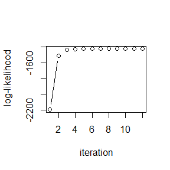

```r
plot(c(1:length(logl)), logl, type = "b", xlab = "iteration", ylab = " log-likelihood")
```

We can see that the EM algorithm converged in $12$ iterations (within $< 1.5e-8$) to the estimate and the log-likelihood values are increasing.

## Question2

Use both for loops and lapply() to fit linear models to the mtcars using the formulas stored in this list:

formulas <- list(

mpg ~ disp,

mpg ~ I(1 / disp),

mpg ~ disp + wt,

mpg ~ I(1 / disp) + wt

)

### Answer

```r
attach(mtcars)

formulas = list(
  mpg ~ disp,
  mpg ~ I(1 / disp),
  mpg ~ disp + wt,
  mpg ~ I(1 / disp) + wt
)
#1 for loops
f3 = vector("list", length(formulas))
for (i in seq_along(formulas)){
  f3[[i]] = lm(formulas[[i]], data = mtcars)
}
f3
```

```
## [[1]]
##
## Call:
## lm(formula = formulas[[i]], data = mtcars)
##
## Coefficients:
## (Intercept)         disp
##    29.59985     -0.04122
##
##
## [[2]]
##
## Call:
## lm(formula = formulas[[i]], data = mtcars)
##
## Coefficients:
## (Intercept)    I(1/disp)
##       10.75      1557.67
##
##
## [[3]]
##
## Call:
## lm(formula = formulas[[i]], data = mtcars)
##
## Coefficients:
## (Intercept)         disp           wt
##    34.96055     -0.01772     -3.35083
##
##
## [[4]]
##
## Call:
## lm(formula = formulas[[i]], data = mtcars)
##
## Coefficients:
## (Intercept)    I(1/disp)           wt
##      19.024     1142.560       -1.798
```

```r
#2 lapply
la3 = lapply(formulas, function(x) lm(formula = x, data = mtcars))
la3
```

```
## [[1]]
##
## Call:
## lm(formula = x, data = mtcars)
##
## Coefficients:
## (Intercept)         disp
##    29.59985     -0.04122
##
##
## [[2]]
##
## Call:
## lm(formula = x, data = mtcars)
##
## Coefficients:
## (Intercept)    I(1/disp)
##       10.75      1557.67
##
##
## [[3]]
##
## Call:
## lm(formula = x, data = mtcars)
##
## Coefficients:
## (Intercept)         disp           wt
##    34.96055     -0.01772     -3.35083
##
##
## [[4]]
##
## Call:
## lm(formula = x, data = mtcars)
##
## Coefficients:
## (Intercept)    I(1/disp)           wt
##      19.024     1142.560       -1.798
```

## Question3

The following code simulates the performance of a t-test for non-normal data. Use sapply() and an anonymous function to extract the p-value from every trial.

```r
trials <- replicate(
  100,
  t.test(rpois(10, 10), rpois(7, 10)),
  simplify = FALSE
)
```

Extra challenge: get rid of the anonymous function by using [[ directly.

## Answer

```r
# anonymous
sapply(trials, function(x) x$p.value)
```

```
##   [1] 0.227748235 0.149994950 0.883108507 0.264311632 0.127448333 0.920913400
##   [7] 0.931294966 0.397824834 0.186032836 0.827777211 0.679364249 0.681804148
##  [13] 0.765292337 0.697016440 0.519683485 0.190377388 0.037312408 0.389007667
##  [19] 0.987306731 0.213516966 0.469453923 0.260356822 0.035520103 0.188985152
##  [25] 0.398950796 0.674235771 0.357375326 0.722854117 0.299920385 0.224471681
##  [31] 0.188041608 0.969567477 0.355925204 0.830743426 0.084848164 0.029084789
##  [37] 0.554507349 0.081002445 0.346120772 0.849636595 0.508356759 0.043204432
##  [43] 0.759333990 0.428173845 0.989367230 0.540508648 0.975219898 0.496502980
##  [49] 0.378205480 0.026046911 0.614273248 0.756848069 0.004530641 0.125469501
##  [55] 0.589426417 0.680088087 0.591129436 0.409742395 0.549733237 0.068884067
##  [61] 0.460903457 0.528185071 0.466381822 0.265211268 0.666161297 0.240404033
##  [67] 0.979468895 0.732099463 0.473083165 0.821075890 0.236983520 0.209609150
##  [73] 0.192307168 0.048508207 0.816193538 0.538143289 0.706754831 0.400589060
##  [79] 0.960858085 0.055077639 0.198504432 0.475232328 0.081050383 0.066484079
##  [85] 0.023812262 0.130528407 0.192283821 0.598449726 0.372639562 0.056456904
##  [91] 0.087985509 0.919338540 0.221305174 0.745371835 0.358558256 0.349803718
##  [97] 0.801603896 0.653685790 0.205898733 0.590258461
```

```r
# without anonymous function
sapply(trials, '[[', "p.value")
```

```
##   [1] 0.227748235 0.149994950 0.883108507 0.264311632 0.127448333 0.920913400
##   [7] 0.931294966 0.397824834 0.186032836 0.827777211 0.679364249 0.681804148
##  [13] 0.765292337 0.697016440 0.519683485 0.190377388 0.037312408 0.389007667
##  [19] 0.987306731 0.213516966 0.469453923 0.260356822 0.035520103 0.188985152
##  [25] 0.398950796 0.674235771 0.357375326 0.722854117 0.299920385 0.224471681
##  [31] 0.188041608 0.969567477 0.355925204 0.830743426 0.084848164 0.029084789
##  [37] 0.554507349 0.081002445 0.346120772 0.849636595 0.508356759 0.043204432
##  [43] 0.759333990 0.428173845 0.989367230 0.540508648 0.975219898 0.496502980
##  [49] 0.378205480 0.026046911 0.614273248 0.756848069 0.004530641 0.125469501
##  [55] 0.589426417 0.680088087 0.591129436 0.409742395 0.549733237 0.068884067
##  [61] 0.460903457 0.528185071 0.466381822 0.265211268 0.666161297 0.240404033
##  [67] 0.979468895 0.732099463 0.473083165 0.821075890 0.236983520 0.209609150
##  [73] 0.192307168 0.048508207 0.816193538 0.538143289 0.706754831 0.400589060
##  [79] 0.960858085 0.055077639 0.198504432 0.475232328 0.081050383 0.066484079
##  [85] 0.023812262 0.130528407 0.192283821 0.598449726 0.372639562 0.056456904
##  [91] 0.087985509 0.919338540 0.221305174 0.745371835 0.358558256 0.349803718
##  [97] 0.801603896 0.653685790 0.205898733 0.590258461
```

## Question4

Implement a combination of Map() and vapply() to create an lapply() variant that iterates in parallel over all of its inputs and stores its outputs in a vector (or a matrix). What arguments should the function take?

## Answer

```r
Mvap <- function(x, fun, value){
  out <- Map(function(y) vapply(y, fun, value), x)
  unlist(out)
}
options(warn = -1)
testlist <- list(cars, faithful, iris)
Mvap(testlist, mean, numeric(1))
```

```
##        speed         dist    eruptions      waiting Sepal.Length  Sepal.Width
##    15.400000    42.980000     3.487783    70.897059     5.843333     3.057333
## Petal.Length  Petal.Width      Species
##     3.758000     1.199333           NA
```

## Homework-12.1

## Question

- Write an Rcpp function for Exercise 9.4 (page 277, Statistical Computing with R).
- Compare the corresponding generated random numbers with those by the R function you wrote before using the function “qqplot”.
- Campare the computation time of the two functions with the function “microbenchmark”.
- Comments your results.

## Answer

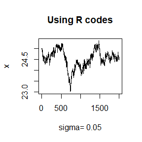

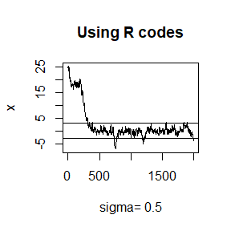

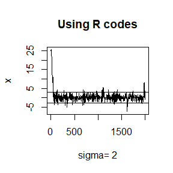

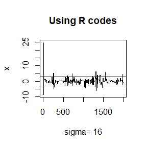

```r
library(Rcpp)
library(GeneralizedHyperbolic)
library(microbenchmark)
f <- function(x) 0.5*exp(-abs(x))
rwMetropolosR <- function(sigma, x0, N){
  x <- numeric(N)
  x[1] <- x0
  u <- runif(N)
  k <- 0
  for (i in 2:N) {
    y <- rnorm(1, x[i-1], sigma)
    if (u[i] <= f(y)/f(x[i-1]))
      x[i] <- y
    else {
      x[i] <- x[i-1]
      k <- k+1
    }
  }
  return(list(x = x,k = k))
}
cppFunction('NumericVector rwMetropolosC(double sigma, double x0, int N){
  NumericVector x(N+1);
  double k=0;
  x[0]=x0;
  double y=0;
  NumericVector u(N);
  for (int i=0;i<N;i++){
    u[i]=runif(1)[0];
  }
  for (int j=1;j<N-1;j++){
    y=rnorm(1,x[j-1],sigma)[0];
    if (u[j]<=0.5*exp(-abs(y))/(0.5*exp(-abs(x[j-1]))))
      x[j]=y;
    else {
      x[j]=x[j-1];
      k++;
    }
  }
  x[N]=k;
  return x;
}')
N <- 2e3
set.seed(1234)
sigma <- c(.05, .5, 2, 16)
x0 <- 25
#rwMetropolosR() returns a list with x and k, with the sample vector and the rejection number.
rwR1 <- rwMetropolosR(sigma[1],x0,N)
rwR2 <- rwMetropolosR(sigma[2],x0,N)
rwR3 <- rwMetropolosR(sigma[3],x0,N)
rwR4 <- rwMetropolosR(sigma[4],x0,N)
#rwMetropolosC() returns a vector x, with the first N the sample and the last the rejection number.
rwC1 <- rwMetropolosC(sigma[1],x0,N)
rwC2 <- rwMetropolosC(sigma[2],x0,N)
rwC3 <- rwMetropolosC(sigma[3],x0,N)
rwC4 <- rwMetropolosC(sigma[4],x0,N)
refline <- qskewlap(c(.025, .975))
rwR <- list(rwR1,rwR2,rwR3,rwR4)
rwC <- list(rwC1,rwC2,rwC3,rwC4)
for (i in 1:4){
  plot(1:2000, rwR[[i]]$x, type = "l", xlab = paste("sigma=",sigma[i]), ylab = "x", main = "Using R codes")
  abline(h=refline)
}
```

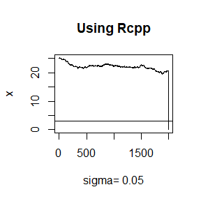

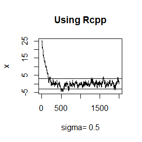

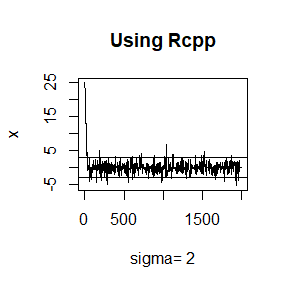

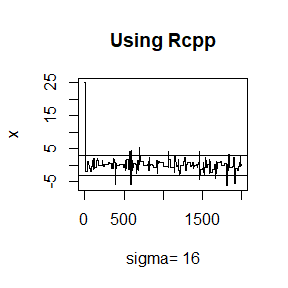

```r
for (i in 1:4) {
  plot(1:2000, rwC[[i]][1:2000], type = "l", xlab = paste("sigma=",sigma[i]), ylab = "x", main = "Using Rcpp")
  abline(h=refline)
}
```